# RRN water-colour and cyclone pressure assessment

Freshwater proxy validation and blocked mortality-model ablations

# Decision

The RRN water-colour layer is a **useful additional freshwater/plume proxy**, but not a replacement for IMOS Kd490 or direct salinity. Absolute WQC has a positive all-event Bayesian association with mortality and gives more consistent unseen-event prediction than a within-reef preceding-decade percentile. The DHW-by-WQC interaction remains uncertain.

The cyclone-wave layer is ecologically useful for separating potential mechanical cyclone exposure from thermal mortality. Its predictive gain is small and programme-specific, and the Bayesian mean-response effect is not positive after adjustment for the core ecological variables.

The weather + raw WQC + cyclone candidate is retained for the predictive ensemble: it improves overall leave-one-event-out RMSE relative to weather alone and has the lowest overall reef-blocked 2024 RMSE. It is not used as the sole production route because gains vary by programme and WQC arrives one wet season late. Rainfall/Kd490 remains the operational fallback.

Modelled COTS pressure is retained in the research data but is not promoted to the predictive route. Adding it worsens blocked BRT prediction and produces no meaningful LOO improvement or clearly supported BRMS mean effect.

# Reef identity and disturbance-lineage correction

The earlier cleaned-name crosswalk collapsed `MACKAY REEF` and `MACKAY REEFS` to the same key. Exact-name-first matching now assigns the raw 2024 AIMS survey and its Jasper/flood-water tooltip to **Mackay Reef (`16-015`)**, not Mackay Reefs (`15-024`). Both manta and LTMP benthic rows now use the correct `16-015` coordinates and an observed pre-event Acropora proportion of 0.111. The raw disturbance tooltip is retained in the canonical outcome tables and provides explicit bleaching, cyclone and flood flags.

# Data alignment and coverage

The supplied workbook uses austral-summer codes. Summer `202324` ends in 2024 and is therefore aligned to the 2024 bleaching-mortality event. This season is present for WQC, cyclone waves and the observed/modelled COTS layers. The release delay affects when the water-colour layer becomes available, not its retrospective coverage of 2024.

The reef-relative WQC feature is the mid-rank of the current frequency against only the preceding ten event years; the current event is excluded from its reference distribution. Modelled IDW COTS is used for prediction because raw manta-tow counts are absent at unsurveyed reefs. Sixteen 2024 MMP observations at four reefs lack the modelled COTS surface and are imputed from each analysis fold rather than from the assessment data.

The extracted layer contains 3,862 GBRMPA reef IDs. It matches all 537 mortality observations directly by `LABEL_ID` and event year; no coordinate matching or imputation is needed. In the larger eReefs grid, the RRN reef set covers about 53.5% of cells in each complete salinity year.

Overlap used for salinity-proxy validation

| Year | eReefs cells | RRN water-colour cells | RRN cyclone cells | Overlap (%) |
| --- | --- | --- | --- | --- |
| 2016 | 7063 | 3781 | 3781 | 53.5 |
| 2017 | 7063 | 3781 | 3781 | 53.5 |
| 2020 | 7063 | 3781 | 3781 | 53.5 |
| 2022 | 7063 | 3781 | 3781 | 53.5 |

# Does water colour reproduce low-salinity patterns?

Proxy validation uses only the complete 2016, 2017, 2020 and 2022 eReefs January–March salinity fields. The partial 2024 salinity field is excluded. There are only 47 below-30 PSU reef-cells among 15,120 matched reef-years, so ordinary classification accuracy would be uninformative. Models are compared by leave-one-event-out average precision, ROC AUC, balanced Brier score, and continuous minimum-salinity error.

Leave-one-event-out salinity-proxy performance

| Proxy | n | Below-30 cells | Average precision | ROC AUC | Balanced Brier | Minimum-salinity RMSE | Minimum-salinity MAE | Minimum-salinity R2 |
| --- | --- | --- | --- | --- | --- | --- | --- | --- |
| IMOS Kd490 | 15120 | 47 | 0.159 | 0.980 | 0.401 | 0.641 | 0.340 | 0.244 |
| RRN water colour + rainfall | 15120 | 47 | 0.146 | 0.910 | 0.391 | 0.628 | 0.324 | 0.276 |
| RRN water colour | 15120 | 47 | 0.133 | 0.978 | 0.396 | 0.655 | 0.342 | 0.210 |
| Spatial baseline | 15120 | 47 | 0.131 | 0.973 | 0.405 | 0.659 | 0.344 | 0.200 |
| Water colour + rainfall + Kd490 | 15120 | 47 | 0.127 | 0.958 | 0.421 | 0.610 | 0.322 | 0.316 |
| ERA5 rainfall | 15120 | 47 | 0.101 | 0.945 | 0.442 | 0.630 | 0.327 | 0.270 |

Water colour alone identifies rare below-30 PSU cells better than rainfall alone (average precision 0.133 versus 0.101) and is similar to the spatial baseline. Combining water colour with rainfall improves average precision to 0.146. IMOS Kd490 remains the best single classifier at 0.159. For continuous minimum salinity, the combined water-colour, rainfall and Kd490 model performs best (RMSE 0.610 PSU, predictive R2 0.316).

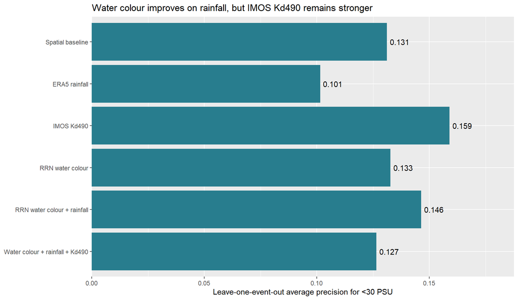

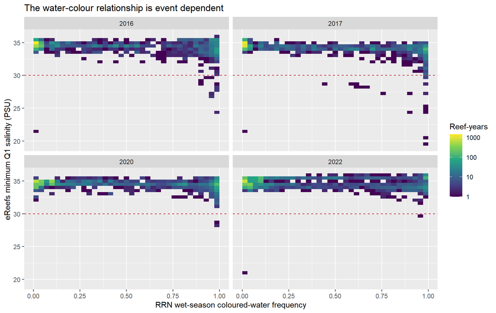

Spearman correlation with minimum salinity is -0.397 in 2016 and -0.658 in 2017, but weak in 2022. The product is therefore informative without being a direct salinity substitute.

# Does either layer improve mortality prediction?

Every BRT candidate retains DHW response shape, preceding Acropora proportion, initial coral cover, prior heat exposure, IMOS Kd490, cloud, depth and programme effects. The only difference is the added pressure block. Each candidate is tuned within identical outer folds.

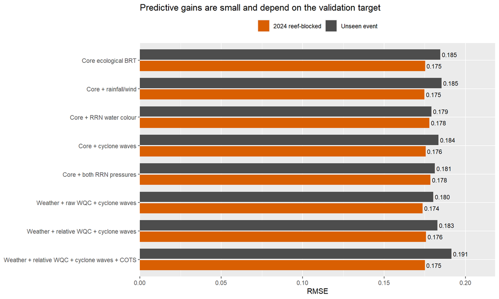

For a completely unseen event, core + raw water colour has the lowest overall RMSE (0.179). Adding raw WQC and cyclone waves to the weather model improves RMSE from 0.185 to 0.180. Replacing raw WQC with the preceding-decade percentile is weaker (0.183), and adding modelled COTS worsens RMSE to 0.191.

For strict reef-blocked 2024 prediction, weather + raw WQC + cyclone waves has the lowest overall RMSE (0.174) and predictive R2 of 0.285. The corresponding COTS candidate has RMSE 0.175 and higher severe-case MAE, so COTS does not clear the predictive gate.

Strict reef-blocked 2024 performance by programme

| Programme | Model | RMSE | MAE | Severe MAE | Observed - predicted |
| --- | --- | --- | --- | --- | --- |
| LTMP benthic | Core ecological BRT | 0.110 | 0.081 | 0.155 | -0.014 |
| LTMP benthic | Weather + relative WQC + cyclone waves + COTS | 0.111 | 0.085 | 0.151 | -0.019 |
| LTMP benthic | Weather + relative WQC + cyclone waves | 0.111 | 0.085 | 0.147 | -0.021 |
| LTMP benthic | Core + both RRN pressures | 0.113 | 0.082 | 0.170 | -0.010 |
| LTMP benthic | Core + cyclone waves | 0.113 | 0.083 | 0.155 | -0.015 |
| LTMP benthic | Core + RRN water colour | 0.113 | 0.084 | 0.167 | -0.012 |
| LTMP benthic | Core + rainfall/wind | 0.113 | 0.085 | 0.152 | -0.023 |
| LTMP benthic | Weather + raw WQC + cyclone waves | 0.115 | 0.087 | 0.156 | -0.023 |
| MMP inshore | Core + cyclone waves | 0.244 | 0.167 | 0.254 | 0.067 |
| MMP inshore | Core ecological BRT | 0.246 | 0.165 | 0.255 | 0.071 |
| MMP inshore | Core + both RRN pressures | 0.248 | 0.168 | 0.253 | 0.062 |
| MMP inshore | Weather + raw WQC + cyclone waves | 0.249 | 0.171 | 0.238 | 0.045 |
| MMP inshore | Core + RRN water colour | 0.250 | 0.171 | 0.251 | 0.060 |
| MMP inshore | Core + rainfall/wind | 0.254 | 0.171 | 0.245 | 0.053 |
| MMP inshore | Weather + relative WQC + cyclone waves + COTS | 0.254 | 0.172 | 0.254 | 0.062 |
| MMP inshore | Weather + relative WQC + cyclone waves | 0.257 | 0.175 | 0.252 | 0.057 |
| Manta tow | Core + rainfall/wind | 0.158 | 0.126 | 0.177 | 0.024 |
| Manta tow | Weather + relative WQC + cyclone waves | 0.158 | 0.127 | 0.176 | 0.024 |
| Manta tow | Weather + raw WQC + cyclone waves | 0.159 | 0.127 | 0.180 | 0.026 |
| Manta tow | Weather + relative WQC + cyclone waves + COTS | 0.160 | 0.126 | 0.181 | 0.029 |
| Manta tow | Core ecological BRT | 0.168 | 0.131 | 0.186 | 0.035 |
| Manta tow | Core + cyclone waves | 0.169 | 0.132 | 0.185 | 0.034 |
| Manta tow | Core + RRN water colour | 0.170 | 0.131 | 0.191 | 0.040 |
| Manta tow | Core + both RRN pressures | 0.173 | 0.135 | 0.196 | 0.041 |

# What happens at severe 2024 manta reefs?

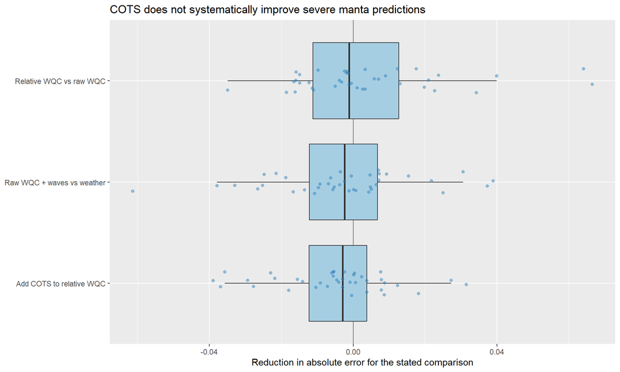

Largest severe 2024 manta underpredictions

| Reef | Region | DHW | Pre-event Acropora | Water colour | Within-reef WQC percentile | Cyclone hours | Modelled COTS/tow | Observed | Core underprediction | Water-colour underprediction | Cyclone underprediction | Weather underprediction | Full candidate underprediction | Disturbance |
| --- | --- | --- | --- | --- | --- | --- | --- | --- | --- | --- | --- | --- | --- | --- |
| Mackay Reef (16-015) | Central GBR | 3.52 | 11% | 0.067 | 80% | 0.0 | 0.0004 | 0.613 | 0.508 | 0.528 | 0.516 | 0.433 | 0.441 | DHW 4.03 coral bleaching, Cyclone Jasper, flood waters |
| Linnet Reef (14-126) | Northern GBR | 6.73 | 63% | 0.537 | 100% | 0.0 | 0.0201 | 0.715 | 0.473 | 0.492 | 0.484 | 0.475 | 0.488 | DHW 6.73 coral bleaching |
| Penrith Reef (21-025) | Southern GBR | 8.25 | 2% | 0.000 | 40% | 4.0 | 0.0000 | 0.421 | 0.389 | 0.390 | 0.397 | 0.383 | 0.376 | NA |
| Lizard Island Reef (North West) (14-116a) | Northern GBR | 6.27 | 15% | 0.047 | 60% | 0.0 | 0.0000 | 0.462 | 0.368 | 0.385 | 0.360 | 0.317 | 0.344 | DHW 6.27 aerial bl 4 coral bleaching |
| Hastings Reef (16-057) | Central GBR | 7.62 | 18% | 0.082 | 90% | 38.0 | 0.0002 | 0.429 | 0.364 | 0.380 | 0.327 | 0.319 | 0.308 | Jasper Jasper Cyclone Jasper, coral bleaching |
| Eyrie Reef (14-118) | Northern GBR | 6.27 | 52% | 0.388 | 100% | 0.0 | 0.0613 | 0.526 | 0.334 | 0.370 | 0.346 | 0.277 | 0.302 | DHW 6.27 to 6.32 coral bleaching |
| Myrmidon Reef (18-034) | Central GBR | 8.73 | 16% | 0.000 | 50% | 9.0 | 0.0000 | 0.364 | 0.294 | 0.296 | 0.299 | 0.257 | 0.270 | DHW 7.18 coral bleaching |
| Swinger Reef (15-030) | Northern GBR | 3.87 | 57% | 0.150 | 100% | 0.0 | 0.0025 | 0.346 | 0.262 | 0.285 | 0.259 | 0.116 | 0.131 | DHW 3.87 coral bleaching |
| U/N Reef (22-084) | Southern GBR | 8.47 | 10% | 0.045 | 100% | 0.0 | 0.0144 | 0.297 | 0.256 | 0.256 | 0.252 | 0.247 | 0.263 | NA |
| Corbett Reef (14-016) | Northern GBR | 7.49 | 30% | 0.580 | 100% | 0.0 | 0.0000 | 0.420 | 0.256 | 0.258 | 0.248 | 0.286 | 0.301 | Aerial bl 3 2024 DHW 6.82 coral bleaching |
| Hoskyn Islands Reef (23-080) | Southern GBR | 11.20 | 88% | 0.045 | 85% | 0.0 | 0.0161 | 0.548 | 0.231 | 0.211 | 0.221 | 0.189 | 0.204 | DHW 11.48 coral bleaching |
| MacGillivray Reef (14-114) | Northern GBR | 5.93 | 22% | 0.043 | 80% | 0.0 | 0.0092 | 0.389 | 0.227 | 0.213 | 0.254 | 0.160 | 0.148 | DHW 6.03 coral bleaching |
| John Brewer Reef (18-075) | Central GBR | 5.79 | 26% | 0.000 | 45% | 3.5 | 0.0187 | 0.262 | 0.220 | 0.220 | 0.226 | 0.231 | 0.229 | Cyclone Kirrily Kirrily Cyclone Kirrily, coral bleaching |
| U/N Reef (21-060) | Southern GBR | 8.99 | 42% | 0.000 | 40% | 1.0 | 0.0000 | 0.316 | 0.217 | 0.207 | 0.206 | 0.237 | 0.234 | NA |
| U/N Reef (20-348) | Southern GBR | 8.39 | 28% | 0.000 | 35% | 18.1 | 0.0303 | 0.320 | 0.208 | 0.184 | 0.188 | 0.188 | 0.168 | Aerial bl 3 2024 DHW 8.39 2024 coral bleaching |

Hastings Reef has substantial modelled 4 m-wave exposure and benefits from the cyclone candidate. High-WQC cases also improve slightly on average. However, the variables do not explain the largest residuals consistently. Corrected Mackay (`16-015`) remains underpredicted by about 0.44 even with rainfall, relative WQC, cyclone waves and COTS. Its retained tooltip explicitly identifies bleaching, Cyclone Jasper and flood waters, indicating that seasonal/grid-scale proxies still miss the acute local freshwater exposure. Linnet, Lizard Island NW, Eyrie and Swinger also remain ecological review priorities.

# Bayesian mechanism check

Regularised all-event RRN pressure BRMS

| Effect | Estimate | 2.5% | 97.5% | P(positive) |
| --- | --- | --- | --- | --- |
| Rainfall: positive-mortality mean | 0.457 | 0.228 | 0.682 | 1.000 |
| Water colour: positive-mortality mean | 0.287 | -0.006 | 0.587 | 0.971 |
| Cyclone waves: positive-mortality mean | -0.074 | -0.221 | 0.069 | 0.160 |
| DHW x rainfall: positive-mortality mean | -0.061 | -0.224 | 0.098 | 0.223 |
| DHW x water colour: positive-mortality mean | 0.071 | -0.069 | 0.217 | 0.830 |
| Water colour: zero/one probability | -0.029 | -0.342 | 0.288 | 0.420 |
| Cyclone waves: zero/one probability | -0.094 | -0.295 | 0.108 | 0.180 |
| COTS: positive-mortality mean | 0.050 | -0.096 | 0.190 | 0.754 |
| COTS: zero/one probability | -0.141 | -0.345 | 0.055 | 0.076 |

Rainfall has strong positive support (standardised logit-scale estimate 0.457, 95% interval 0.228–0.682). Absolute WQC is also probably positive (0.287, interval -0.006–0.587, P[positive] = 0.971), while its DHW interaction remains uncertain. The cyclone-wave mean effect is weakly negative and uncertain.

The COTS mean effect is small and uncertain (0.050, interval -0.096–0.190, P[positive] = 0.754). Its addition changes Bayesian R2 only from 0.334 to 0.338 and improves expected log predictive density by 0.1 with a standard error of 1.6: effectively no LOO difference. Because both fits contain many high Pareto-k observations, the blocked BRT comparison is the stronger predictive evidence and also rejects COTS as a production improvement.

Matched BRMS model-fit comparison

| Model | ELPD difference | SE difference | LOOIC | Bayesian R2 |
| --- | --- | --- | --- | --- |
| Rainfall + WQC + cyclone waves | -0.05 | 1.58 | 301.2 | 0.334 |
| Rainfall + WQC + cyclone waves + COTS | 0.00 | 0.00 | 301.1 | 0.338 |

RRN pressure BRMS diagnostics

| model | Maximum R-hat | Minimum bulk ESS | Minimum tail ESS | Divergences | Tree-depth hits | Pass gate |
| --- | --- | --- | --- | --- | --- | --- |
| weather_rrn | 1.007 | 722.553 | 1477.512 | 0 | 0 | TRUE |
| weather_rrn_cots | 1.008 | 721.128 | 1024.769 | 0 | 0 | TRUE |

# Recommended pipeline use

1. Retain rainfall, raw `wqc_freqcc12` and `cyc_maxHrs4mw` as distinct predictors in the RRN ensemble candidate. Do not call WQC measured salinity or treat cyclone wave-hours as a freshwater metric.
2. Retain the preceding-decade WQC percentile as an anomaly diagnostic and future candidate, but prefer raw WQC in the current predictive route.
3. Retain observed and IDW-modelled COTS fields in the research data. Do not require COTS in the production route until blocked validation improves.
4. Retain IMOS Kd490 and rainfall as operational inputs when annual WQC is not yet available.
5. Preserve the largest unexplained severe residuals as ecological review targets rather than flattening the DHW response or treating them as noise.

# Status of the shared latent ecological response

The current joint BRMS is a **shared-effects pooled response model**, not yet a full latent ecological-state model. It shares ecological slopes and a reef-event random effect while allowing programme-specific mean intercepts, beta precision and zero/one probabilities. The BRT likewise includes programme as a predictor and balances reef-event weights.

The remaining architecture is to estimate one latent reef-event mortality state and link manta tow, LTMP photo transects and MMP observations to it with separate programme-specific observation equations, bias, precision and detection behaviour. That is the next formal modelling stage now that the pressure feature set has been screened.